# wrangle_act

```python
pip install tweepy
```

```python
import tweepy
import json
import matplotlib.pyplot as plt
import numpy as np
import pandas as pd
import re
import os
import requests
import seaborn as sns
```

```python
%matplotlib inline
plt.rcParams['figure.figsize'] = (20,20)
```

### Data Gathering:

- Importing twitter-archive-enhanced csv file.
- Importing image_predections using `requests`.
- Importing tweet_json.

```python
twitter_enhanced = pd.read_csv("twitter-archive-enhanced.csv")
```

```python
url = 'https://d17h27t6h515a5.cloudfront.net/topher/2017/August/599fd2ad_image-predictions/image-predictions.tsv'
response = requests.get(url)
```

```python
with open(os.path.join('image_predictions.tsv'), mode = 'wb') as file:
    file.write(response.content)
```

```python
image_pred = pd.read_csv('image_predictions.tsv', sep='\t')
```

```python
consumer_key = 'X'
consumer_secret = 'X'
access_token = 'X'
access_secret = 'X'

auth = tweepy.OAuthHandler(consumer_key, consumer_secret)
auth.set_access_token(access_token, access_secret)

api = tweepy.API(auth, parser=tweepy.parsers.JSONParser())
```

```python
twitter = pd.read_json('tweet_json.txt')
```

### Data Assesing

- Dataset: twitter_enhanced

```python
twitter_enhanced.sample(4)
```

|  | tweet_id | in_reply_to_status_id | in_reply_to_user_id | timestamp | source | text | retweeted_status_id | retweeted_status_user_id | retweeted_status_timestamp | expanded_urls | rating_numerator | rating_denominator | name | doggo | floofer | pupper | puppo |
| --- | --- | --- | --- | --- | --- | --- | --- | --- | --- | --- | --- | --- | --- | --- | --- | --- | --- |
| 2223 | 668297328638447616 | NaN | NaN | 2015-11-22 05:17:54 +0000 | <a href="http://twitter.com/download/iphone" r... | 2 rare dogs. They waddle (v inefficient). Some... | NaN | NaN | NaN | https://twitter.com/dog_rates/status/668297328... | 9 | 10 | None | None | None | None | None |
| 1290 | 708130923141795840 | NaN | NaN | 2016-03-11 03:22:23 +0000 | <a href="http://twitter.com/download/iphone" r... | Please stop sending in non canines like this G... | NaN | NaN | NaN | https://twitter.com/dog_rates/status/708130923... | 11 | 10 | None | None | None | None | None |
| 1223 | 714251586676113411 | NaN | NaN | 2016-03-28 00:43:43 +0000 | <a href="http://twitter.com/download/iphone" r... | This is Thumas. He hates potted plants. 8/10 w... | NaN | NaN | NaN | https://twitter.com/dog_rates/status/714251586... | 8 | 10 | Thumas | None | None | None | None |
| 686 | 788070120937619456 | NaN | NaN | 2016-10-17 17:32:13 +0000 | <a href="http://twitter.com/download/iphone" r... | RT @dog_rates: This is Bo and Ty. Bo eats pape... | 7.610045e+17 | 4.196984e+09 | 2016-08-04 01:03:17 +0000 | https://twitter.com/dog_rates/status/761004547... | 11 | 10 | Bo | None | None | None | None |

```python
twitter_enhanced.info()
```

```
<class 'pandas.core.frame.DataFrame'>
RangeIndex: 2356 entries, 0 to 2355
Data columns (total 17 columns):
 #   Column                      Non-Null Count  Dtype
---  ------                      --------------  -----
 0   tweet_id                    2356 non-null   int64
 1   in_reply_to_status_id       78 non-null     float64
 2   in_reply_to_user_id         78 non-null     float64
 3   timestamp                   2356 non-null   object
 4   source                      2356 non-null   object
 5   text                        2356 non-null   object
 6   retweeted_status_id         181 non-null    float64
 7   retweeted_status_user_id    181 non-null    float64
 8   retweeted_status_timestamp  181 non-null    object
 9   expanded_urls               2297 non-null   object
 10  rating_numerator            2356 non-null   int64
 11  rating_denominator          2356 non-null   int64
 12  name                        2356 non-null   object
 13  doggo                       2356 non-null   object
 14  floofer                     2356 non-null   object
 15  pupper                      2356 non-null   object
 16  puppo                       2356 non-null   object
dtypes: float64(4), int64(3), object(10)
memory usage: 313.0+ KB
```

```python
twitter_enhanced.isnull().sum()
```

```
tweet_id                         0
in_reply_to_status_id         2278
in_reply_to_user_id           2278
timestamp                        0
source                           0
text                             0
retweeted_status_id           2175
retweeted_status_user_id      2175
retweeted_status_timestamp    2175
expanded_urls                   59
rating_numerator                 0
rating_denominator               0
name                             0
doggo                            0
floofer                          0
pupper                           0
puppo                            0
dtype: int64
```

```python
twitter_enhanced.nunique()
```

```
tweet_id                      2356
in_reply_to_status_id           77
in_reply_to_user_id             31
timestamp                     2356
source                           4
text                          2356
retweeted_status_id            181
retweeted_status_user_id        25
retweeted_status_timestamp     181
expanded_urls                 2218
rating_numerator                40
rating_denominator              18
name                           957
doggo                            2
floofer                          2
pupper                           2
puppo                            2
dtype: int64
```

```python
twitter_enhanced['source'].value_counts()
```

```
<a href="http://twitter.com/download/iphone" rel="nofollow">Twitter for iPhone</a>     2221
<a href="http://vine.co" rel="nofollow">Vine - Make a Scene</a>                          91
<a href="http://twitter.com" rel="nofollow">Twitter Web Client</a>                       33
<a href="https://about.twitter.com/products/tweetdeck" rel="nofollow">TweetDeck</a>      11
Name: source, dtype: int64
```

```python
twitter_enhanced['rating_numerator'].value_counts()
```

```
12      558
11      464
10      461
13      351
9       158
8       102
7        55
14       54
5        37
6        32
3        19
4        17
1         9
2         9
420       2
```

[output cut: 26 more lines]

```python
twitter_enhanced['rating_denominator'].value_counts()
```

```
10     2333
11        3
50        3
80        2
20        2
2         1
16        1
40        1
70        1
15        1
90        1
110       1
120       1
130       1
150       1
170       1
7         1
0         1
Name: rating_denominator, dtype: int64
```

```python
twitter_enhanced['name'].value_counts()
```

```
None       745
a           55
Charlie     12
Cooper      11
Lucy        11
          ...
Cheryl       1
Alfy         1
Billy        1
Autumn       1
Gunner       1
Name: name, Length: 957, dtype: int64
```

```python
twitter_enhanced.isnull().sum()
```

```
tweet_id                         0
in_reply_to_status_id         2278
in_reply_to_user_id           2278
timestamp                        0
source                           0
text                             0
retweeted_status_id           2175
retweeted_status_user_id      2175
retweeted_status_timestamp    2175
expanded_urls                   59
rating_numerator                 0
rating_denominator               0
name                             0
doggo                            0
floofer                          0
pupper                           0
puppo                            0
dtype: int64
```

```python
twitter_enhanced.name.unique()
```

```
array(['Phineas', 'Tilly', 'Archie', 'Darla', 'Franklin', 'None', 'Jax',
       'Zoey', 'Cassie', 'Koda', 'Bruno', 'Ted', 'Stuart', 'Oliver',
       'Jim', 'Zeke', 'Ralphus', 'Canela', 'Gerald', 'Jeffrey', 'such',
       'Maya', 'Mingus', 'Derek', 'Roscoe', 'Waffles', 'Jimbo', 'Maisey',
       'Lilly', 'Earl', 'Lola', 'Kevin', 'Yogi', 'Noah', 'Bella',
       'Grizzwald', 'Rusty', 'Gus', 'Stanley', 'Alfy', 'Koko', 'Rey',
       'Gary', 'a', 'Elliot', 'Louis', 'Jesse', 'Romeo', 'Bailey',
       'Duddles', 'Jack', 'Emmy', 'Steven', 'Beau', 'Snoopy', 'Shadow',
       'Terrance', 'Aja', 'Penny', 'Dante', 'Nelly', 'Ginger', 'Benedict',
       'Venti', 'Goose', 'Nugget', 'Cash', 'Coco', 'Jed', 'Sebastian',
       'Walter', 'Sierra', 'Monkey', 'Harry', 'Kody', 'Lassie', 'Rover',
       'Napolean', 'Dawn', 'Boomer', 'Cody', 'Rumble', 'Clifford',
       'quite', 'Dewey', 'Scout', 'Gizmo', 'Cooper', 'Harold', 'Shikha',
       'Jamesy', 'Lili', 'Sammy', 'Meatball', 'Paisley', 'Albus',
       'Neptune', 'Quinn', 'Belle', 'Zooey', 'Dave', 'Jersey', 'Hobbes',
       'Burt', 'Lorenzo', 'Carl', 'Jordy', 'Milky', 'Trooper', 'Winston',
       'Sophie', 'Wyatt', 'Rosie', 'Thor', 'Oscar', 'Luna', 'Callie',
       'Cermet', 'George', 'Marlee', 'Arya', 'Einstein', 'Alice',
       'Rumpole', 'Benny', 'Aspen', 'Jarod', 'Wiggles', 'General',
       'Sailor', 'Astrid', 'Iggy', 'Snoop', 'Kyle', 'Leo', 'Riley',
       'Gidget', 'Noosh', 'Odin', 'Jerry', 'Charlie', 'Georgie', 'Rontu',
       'Cannon', 'Furzey', 'Daisy', 'Tuck', 'Barney', 'Vixen', 'Jarvis',
       'Mimosa', 'Pickles', 'Bungalo', 'Brady', 'Margo', 'Sadie', 'Hank',
       'Tycho', 'Stephan', 'Indie', 'Winnie', 'Bentley', 'Ken', 'Max',
       'Maddie', 'Pipsy', 'Monty', 'Sojourner', 'Odie', 'Arlo', 'Sunny',
       'Vincent', 'Lucy', 'Clark', 'Mookie', 'Meera', 'Buddy', 'Ava',
       'Rory', 'Eli', 'Ash', 'Tucker', 'Tobi', 'Chester', 'Wilson',
       'Sunshine', 'Lipton', 'Gabby', 'Bronte', 'Poppy', 'Rhino',
       'Willow', 'not', 'Orion', 'Eevee', 'Smiley', 'Logan', 'Moreton',
       'Klein', 'Miguel', 'Emanuel', 'Kuyu', 'Dutch', 'Pete', 'Scooter',
       'Reggie', 'Kyro', 'Samson', 'Loki', 'Mia', 'Malcolm', 'Dexter',
       'Alfie', 'Fiona', 'one', 'Mutt', 'Bear', 'Doobert', 'Beebop',
       'Alexander', 'Sailer', 'Brutus', 'Kona', 'Boots', 'Ralphie',
       'Phil', 'Cupid', 'Pawnd', 'Pilot', 'Ike', 'Mo', 'Toby', 'Sweet',
       'Pablo', 'Nala', 'Balto', 'Crawford', 'Gabe', 'Mattie', 'Jimison',
       'Hercules', 'Duchess', 'Harlso', 'Sampson', 'Sundance', 'Luca',
       'Flash', 'Finn', 'Peaches', 'Howie', 'Jazzy', 'Anna', 'Bo',
       'Seamus', 'Wafer', 'Chelsea', 'Tom', 'Moose', 'Florence', 'Autumn',
       'Dido', 'Eugene', 'Herschel', 'Strudel', 'Tebow', 'Chloe', 'Betty',
       'Timber', 'Binky', 'Dudley', 'Comet', 'Larry', 'Levi', 'Akumi',
```

[output cut: 88 more lines]

```
       'Anthony', 'Holly', 'Jett', 'Amy', 'Sage', 'Andy', 'Mason',
       'Trigger', 'Antony', 'Creg', 'Traviss', 'Gin', 'Jeffrie', 'Danny',
       'Ester', 'Pluto', 'Bloo', 'Edd', 'Willy', 'Herb', 'Damon',
       'Peanut', 'Nigel', 'Butters', 'Sandra', 'Fabio', 'Randall', 'Liam',
       'Tommy', 'Ben', 'Raphael', 'Julio', 'Andru', 'Kloey', 'Shawwn',
       'Skye', 'Kollin', 'Ronduh', 'Billl', 'Saydee', 'Dug', 'Tessa',
       'Sully', 'Kirk', 'Ralf', 'Clarq', 'Jaspers', 'Samsom', 'Harrison',
       'Chaz', 'Jeremy', 'Jaycob', 'Lambeau', 'Ruffles', 'Amélie', 'Bobb',
       'Banditt', 'Kevon', 'Winifred', 'Hanz', 'Churlie', 'Zeek',
       'Timofy', 'Maks', 'Jomathan', 'Kallie', 'Marvin', 'Spark',
       'Gòrdón', 'Jo', 'DayZ', 'Jareld', 'Torque', 'Ron', 'Skittles',
       'Cleopatricia', 'Erik', 'Stu', 'Tedrick', 'Filup', 'Kial',
       'Naphaniel', 'Dook', 'Hall', 'Philippe', 'Biden', 'Fwed',
       'Genevieve', 'Joshwa', 'Bradlay', 'Clybe', 'Keet', 'Carll',
       'Jockson', 'Josep', 'Lugan', 'Christoper'], dtype=object)
```

```python
twitter_enhanced.loc[twitter_enhanced.name.str.isupper()]
```

|  | tweet_id | in_reply_to_status_id | in_reply_to_user_id | timestamp | source | text | retweeted_status_id | retweeted_status_user_id | retweeted_status_timestamp | expanded_urls | rating_numerator | rating_denominator | name | doggo | floofer | pupper | puppo |
| --- | --- | --- | --- | --- | --- | --- | --- | --- | --- | --- | --- | --- | --- | --- | --- | --- | --- |
| 775 | 776201521193218049 | NaN | NaN | 2016-09-14 23:30:38 +0000 | <a href="http://twitter.com/download/iphone" r... | This is O'Malley. That is how he sleeps. Doesn... | NaN | NaN | NaN | https://twitter.com/dog_rates/status/776201521... | 10 | 10 | O | None | None | None | None |
| 2041 | 671542985629241344 | NaN | NaN | 2015-12-01 04:14:59 +0000 | <a href="http://twitter.com/download/iphone" r... | This is JD (stands for "just dog"). He's like ... | NaN | NaN | NaN | https://twitter.com/dog_rates/status/671542985... | 10 | 10 | JD | None | None | None | None |

```python
twitter_enhanced.loc[twitter_enhanced.name.str.islower()]
```

|  | tweet_id | in_reply_to_status_id | in_reply_to_user_id | timestamp | source | text | retweeted_status_id | retweeted_status_user_id | retweeted_status_timestamp | expanded_urls | rating_numerator | rating_denominator | name | doggo | floofer | pupper | puppo |
| --- | --- | --- | --- | --- | --- | --- | --- | --- | --- | --- | --- | --- | --- | --- | --- | --- | --- |
| 22 | 887517139158093824 | NaN | NaN | 2017-07-19 03:39:09 +0000 | <a href="http://twitter.com/download/iphone" r... | I've yet to rate a Venezuelan Hover Wiener. Th... | NaN | NaN | NaN | https://twitter.com/dog_rates/status/887517139... | 14 | 10 | such | None | None | None | None |
| 56 | 881536004380872706 | NaN | NaN | 2017-07-02 15:32:16 +0000 | <a href="http://twitter.com/download/iphone" r... | Here is a pupper approaching maximum borkdrive... | NaN | NaN | NaN | https://twitter.com/dog_rates/status/881536004... | 14 | 10 | a | None | None | pupper | None |
| 118 | 869988702071779329 | NaN | NaN | 2017-05-31 18:47:24 +0000 | <a href="http://twitter.com/download/iphone" r... | RT @dog_rates: We only rate dogs. This is quit... | 8.591970e+17 | 4.196984e+09 | 2017-05-02 00:04:57 +0000 | https://twitter.com/dog_rates/status/859196978... | 12 | 10 | quite | None | None | None | None |
| 169 | 859196978902773760 | NaN | NaN | 2017-05-02 00:04:57 +0000 | <a href="http://twitter.com/download/iphone" r... | We only rate dogs. This is quite clearly a smo... | NaN | NaN | NaN | https://twitter.com/dog_rates/status/859196978... | 12 | 10 | quite | None | None | None | None |
| 193 | 855459453768019968 | NaN | NaN | 2017-04-21 16:33:22 +0000 | <a href="http://twitter.com/download/iphone" r... | Guys, we only rate dogs. This is quite clearly... | NaN | NaN | NaN | https://twitter.com/dog_rates/status/855459453... | 12 | 10 | quite | None | None | None | None |
| ... | ... | ... | ... | ... | ... | ... | ... | ... | ... | ... | ... | ... | ... | ... | ... | ... | ... |
| 2349 | 666051853826850816 | NaN | NaN | 2015-11-16 00:35:11 +0000 | <a href="http://twitter.com/download/iphone" r... | This is an odd dog. Hard on the outside but lo... | NaN | NaN | NaN | https://twitter.com/dog_rates/status/666051853... | 2 | 10 | an | None | None | None | None |
| 2350 | 666050758794694657 | NaN | NaN | 2015-11-16 00:30:50 +0000 | <a href="http://twitter.com/download/iphone" r... | This is a truly beautiful English Wilson Staff... | NaN | NaN | NaN | https://twitter.com/dog_rates/status/666050758... | 10 | 10 | a | None | None | None | None |
| 2352 | 666044226329800704 | NaN | NaN | 2015-11-16 00:04:52 +0000 | <a href="http://twitter.com/download/iphone" r... | This is a purebred Piers Morgan. Loves to Netf... | NaN | NaN | NaN | https://twitter.com/dog_rates/status/666044226... | 6 | 10 | a | None | None | None | None |
| 2353 | 666033412701032449 | NaN | NaN | 2015-11-15 23:21:54 +0000 | <a href="http://twitter.com/download/iphone" r... | Here is a very happy pup. Big fan of well-main... | NaN | NaN | NaN | https://twitter.com/dog_rates/status/666033412... | 9 | 10 | a | None | None | None | None |
| 2354 | 666029285002620928 | NaN | NaN | 2015-11-15 23:05:30 +0000 | <a href="http://twitter.com/download/iphone" r... | This is a western brown Mitsubishi terrier. Up... | NaN | NaN | NaN | https://twitter.com/dog_rates/status/666029285... | 7 | 10 | a | None | None | None | None |

109 rows × 17 columns

```python
len(twitter_enhanced.loc[(twitter_enhanced['doggo']== 'doggo') & (twitter_enhanced['floofer']== 'floofer')])
```

```
1
```

```python
len(twitter_enhanced.loc[(twitter_enhanced['doggo']== 'doggo') & (twitter_enhanced['pupper']== 'pupper')])
```

```
12
```

```python
len(twitter_enhanced.loc[(twitter_enhanced['doggo']== 'None') & (twitter_enhanced['floofer']== 'None') & (twitter_enhanced['pupper']== 'None') & (twitter_enhanced['puppo']== 'None')])
```

```
1976
```

```python
len(twitter_enhanced.loc[(twitter_enhanced['floofer']== 'floofer') & (twitter_enhanced['pupper']== 'pupper')])
```

```
0
```

```python
twitter_enhanced.describe()
```

|  | tweet_id | in_reply_to_status_id | in_reply_to_user_id | retweeted_status_id | retweeted_status_user_id | rating_numerator | rating_denominator |
| --- | --- | --- | --- | --- | --- | --- | --- |
| count | 2.356000e+03 | 7.800000e+01 | 7.800000e+01 | 1.810000e+02 | 1.810000e+02 | 2356.000000 | 2356.000000 |
| mean | 7.427716e+17 | 7.455079e+17 | 2.014171e+16 | 7.720400e+17 | 1.241698e+16 | 13.126486 | 10.455433 |
| std | 6.856705e+16 | 7.582492e+16 | 1.252797e+17 | 6.236928e+16 | 9.599254e+16 | 45.876648 | 6.745237 |
| min | 6.660209e+17 | 6.658147e+17 | 1.185634e+07 | 6.661041e+17 | 7.832140e+05 | 0.000000 | 0.000000 |
| 25% | 6.783989e+17 | 6.757419e+17 | 3.086374e+08 | 7.186315e+17 | 4.196984e+09 | 10.000000 | 10.000000 |
| 50% | 7.196279e+17 | 7.038708e+17 | 4.196984e+09 | 7.804657e+17 | 4.196984e+09 | 11.000000 | 10.000000 |
| 75% | 7.993373e+17 | 8.257804e+17 | 4.196984e+09 | 8.203146e+17 | 4.196984e+09 | 12.000000 | 10.000000 |
| max | 8.924206e+17 | 8.862664e+17 | 8.405479e+17 | 8.874740e+17 | 7.874618e+17 | 1776.000000 | 170.000000 |

- Dataset: Twitter

```python
twitter.info()
```

```
<class 'pandas.core.frame.DataFrame'>
RangeIndex: 2345 entries, 0 to 2344
Data columns (total 31 columns):
 #   Column                         Non-Null Count  Dtype
---  ------                         --------------  -----
 0   created_at                     2345 non-null   datetime64[ns, UTC]
 1   id                             2345 non-null   int64
 2   id_str                         2345 non-null   int64
 3   full_text                      2345 non-null   object
 4   truncated                      2345 non-null   bool
 5   display_text_range             2345 non-null   object
 6   entities                       2345 non-null   object
 7   extended_entities              2069 non-null   object
 8   source                         2345 non-null   object
 9   in_reply_to_status_id          78 non-null     float64
```

[output cut: 23 more lines]

```python
twitter.sample(4)
```

|  | created_at | id | id_str | full_text | truncated | display_text_range | entities | extended_entities | source | in_reply_to_status_id | ... | favorite_count | favorited | retweeted | possibly_sensitive | possibly_sensitive_appealable | lang | retweeted_status | quoted_status_id | quoted_status_id_str | quoted_status |
| --- | --- | --- | --- | --- | --- | --- | --- | --- | --- | --- | --- | --- | --- | --- | --- | --- | --- | --- | --- | --- | --- |
| 1714 | 2015-12-24 17:00:27+00:00 | 680070545539371008 | 680070545539371008 | Say hello to Emmie. She's trapped in an orname... | False | [0, 139] | {'hashtags': [], 'symbols': [], 'user_mentions... | {'media': [{'id': 679935050679468032, 'id_str'... | <a href="https://about.twitter.com/products/tw... | NaN | ... | 2755 | False | False | 0.0 | 0.0 | en | NaN | NaN | NaN | NaN |
| 758 | 2016-09-18 21:33:11+00:00 | 777621514455814149 | 777621514455814144 | This is Derek. You can't look at him and not s... | False | [0, 112] | {'hashtags': [], 'symbols': [], 'user_mentions... | {'media': [{'id': 777621500824260608, 'id_str'... | <a href="http://twitter.com/download/iphone" r... | NaN | ... | 9563 | False | False | 0.0 | 0.0 | en | NaN | NaN | NaN | NaN |
| 1779 | 2015-12-17 16:45:31+00:00 | 677530072887205888 | 677530072887205888 | Say hello to Axel. He's a Black Chevy Pinot on... | False | [0, 136] | {'hashtags': [], 'symbols': [], 'user_mentions... | {'media': [{'id': 677530062560841728, 'id_str'... | <a href="http://twitter.com/download/iphone" r... | NaN | ... | 1132 | False | False | 0.0 | 0.0 | en | NaN | NaN | NaN | NaN |
| 1546 | 2016-01-17 19:27:24+00:00 | 688804835492233216 | 688804835492233216 | When you stumble but recover quickly cause you... | False | [0, 96] | {'hashtags': [], 'symbols': [], 'user_mentions... | {'media': [{'id': 688804831675461632, 'id_str'... | <a href="http://twitter.com/download/iphone" r... | NaN | ... | 1027 | False | False | 0.0 | 0.0 | en | NaN | NaN | NaN | NaN |

4 rows × 31 columns

```python
twitter['id'].duplicated().any()
```

```
False
```

```python
twitter.describe()
```

|  | id | id_str | in_reply_to_status_id | in_reply_to_status_id_str | in_reply_to_user_id | in_reply_to_user_id_str | geo | coordinates | contributors | retweet_count | favorite_count | possibly_sensitive | possibly_sensitive_appealable | quoted_status_id | quoted_status_id_str |
| --- | --- | --- | --- | --- | --- | --- | --- | --- | --- | --- | --- | --- | --- | --- | --- |
| count | 2.345000e+03 | 2.345000e+03 | 7.800000e+01 | 7.800000e+01 | 7.800000e+01 | 7.800000e+01 | 0.0 | 0.0 | 0.0 | 2345.000000 | 2345.000000 | 2207.0 | 2207.0 | 2.700000e+01 | 2.700000e+01 |
| mean | 7.422940e+17 | 7.422940e+17 | 7.455079e+17 | 7.455079e+17 | 2.014171e+16 | 2.014171e+16 | NaN | NaN | NaN | 3039.042644 | 8094.136461 | 0.0 | 0.0 | 8.190431e+17 | 8.190431e+17 |
| std | 6.833642e+16 | 6.833642e+16 | 7.582492e+16 | 7.582492e+16 | 1.252797e+17 | 1.252797e+17 | NaN | NaN | NaN | 5053.376270 | 12174.600544 | 0.0 | 0.0 | 5.567966e+16 | 5.567966e+16 |
| min | 6.660209e+17 | 6.660209e+17 | 6.658147e+17 | 6.658147e+17 | 1.185634e+07 | 1.185634e+07 | NaN | NaN | NaN | 0.000000 | 0.000000 | 0.0 | 0.0 | 7.061659e+17 | 7.061659e+17 |
| 25% | 6.783802e+17 | 6.783802e+17 | 6.757419e+17 | 6.757419e+17 | 3.086374e+08 | 3.086374e+08 | NaN | NaN | NaN | 608.000000 | 1407.000000 | 0.0 | 0.0 | 7.924710e+17 | 7.924710e+17 |
| 50% | 7.189392e+17 | 7.189392e+17 | 7.038708e+17 | 7.038708e+17 | 4.196984e+09 | 4.196984e+09 | NaN | NaN | NaN | 1423.000000 | 3549.000000 | 0.0 | 0.0 | 8.340867e+17 | 8.340867e+17 |
| 75% | 7.986979e+17 | 7.986979e+17 | 8.257804e+17 | 8.257804e+17 | 4.196984e+09 | 4.196984e+09 | NaN | NaN | NaN | 3541.000000 | 10010.000000 | 0.0 | 0.0 | 8.611580e+17 | 8.611580e+17 |
| max | 8.924206e+17 | 8.924206e+17 | 8.862664e+17 | 8.862664e+17 | 8.405479e+17 | 8.405479e+17 | NaN | NaN | NaN | 77668.000000 | 143866.000000 | 0.0 | 0.0 | 8.860534e+17 | 8.860534e+17 |

- Dataset: image_pred

```python
image_pred.sample(4)
```

|  | tweet_id | jpg_url | img_num | p1 | p1_conf | p1_dog | p2 | p2_conf | p2_dog | p3 | p3_conf | p3_dog |
| --- | --- | --- | --- | --- | --- | --- | --- | --- | --- | --- | --- | --- |
| 1194 | 740359016048689152 | https://pbs.twimg.com/media/CkZImGVUoAAwv0b.jpg | 1 | golden_retriever | 0.863687 | True | kuvasz | 0.048590 | True | Labrador_retriever | 0.047397 | True |
| 1645 | 808134635716833280 | https://pbs.twimg.com/media/Cx5R8wPVEAALa9r.jpg | 1 | cocker_spaniel | 0.740220 | True | Dandie_Dinmont | 0.061604 | True | English_setter | 0.041331 | True |
| 701 | 684880619965411328 | https://pbs.twimg.com/media/CYEvSaRWwAAukZ_.jpg | 1 | clog | 0.081101 | False | spindle | 0.066957 | False | agama | 0.060884 | False |
| 435 | 674394782723014656 | https://pbs.twimg.com/media/CVvueeeWwAUcQLR.jpg | 1 | toilet_tissue | 0.134983 | False | mosquito_net | 0.133247 | False | Lakeland_terrier | 0.109099 | True |

```python
image_pred.info()
```

```
<class 'pandas.core.frame.DataFrame'>
RangeIndex: 2075 entries, 0 to 2074
Data columns (total 12 columns):
 #   Column    Non-Null Count  Dtype
---  ------    --------------  -----
 0   tweet_id  2075 non-null   int64
 1   jpg_url   2075 non-null   object
 2   img_num   2075 non-null   int64
 3   p1        2075 non-null   object
 4   p1_conf   2075 non-null   float64
 5   p1_dog    2075 non-null   bool
 6   p2        2075 non-null   object
 7   p2_conf   2075 non-null   float64
 8   p2_dog    2075 non-null   bool
 9   p3        2075 non-null   object
 10  p3_conf   2075 non-null   float64
 11  p3_dog    2075 non-null   bool
dtypes: bool(3), float64(3), int64(2), object(4)
memory usage: 152.1+ KB
```

```python
image_pred['tweet_id'].duplicated().any()
```

```
False
```

```python
image_pred['img_num'].value_counts()
```

```
1    1780
2     198
3      66
4      31
Name: img_num, dtype: int64
```

```python
image_pred['p1_dog'].value_counts()
```

```
True     1532
False     543
Name: p1_dog, dtype: int64
```

```python
image_pred['p2_dog'].value_counts()
```

```
True     1553
False     522
Name: p2_dog, dtype: int64
```

```python
image_pred['p3_dog'].value_counts()
```

```
True     1499
False     576
Name: p3_dog, dtype: int64
```

## Quality Issues:

#### Dataset twitter_enhanced:

- There are unnecessary columns.
- There are retweets.
- `expanded_urls` column: tweets/ retweets without images
- `timestamp` is not in datetime format
- `name` has missing data but not NaN, and some names are wrong.
- `tweet_id` should be in type object.
- Some tweets include more than one rating with decimal numbers.
- `pupper`, `puppo`, `floofer` and `doggo` columns: For 1976 IDs there is no dog "stage" information.
- `pupper`, `puppo`, `floofer` and `doggo` columns: There are some IDs with more than one dog "stage" information (two dogs are rated).

#### Dataset twitter:

- `id` should be type object.

#### Dataset image_pred:

- Dog breeds are not lower or uppercase always.
- `tweet_id` should be type object.
- `img_num` column isn't needed

## Tidiness Issues:

- twitter_enhanced: Transform the 4 columns `dogger`, `floofer`, `pupper` and `puppo` into one variable `stage`.
- image_pred: the prediction shall be collected in only one column `breed_pred`
- image_pred: the prediction confidence should be collected int one column `pred_confidence`
- image_pred: `jpg_url`, `breed_pred` and `pred_confidence` should be in one table `twitter_enhanced`.
- twitter: `favorite_count` and `retweet_count` column should be in one table, `twitter_enhanced` Dataset.

### Data Cleaning:

```python
twitter_enhanced_clean = twitter_enhanced.copy()
twitter_clean = twitter.copy()
image_pred_clean = image_pred.copy()
```

##### Merging all sets together in order to do clean only once. (TIDINESS ISSUE)

### First: Quality Issues

```python
df = pd.concat([twitter_enhanced_clean, image_pred_clean, twitter_clean], join='outer', axis=1)
```

```python
df.head()
```

|  | tweet_id | in_reply_to_status_id | in_reply_to_user_id | timestamp | source | text | retweeted_status_id | retweeted_status_user_id | retweeted_status_timestamp | expanded_urls | ... | favorite_count | favorited | retweeted | possibly_sensitive | possibly_sensitive_appealable | lang | retweeted_status | quoted_status_id | quoted_status_id_str | quoted_status |
| --- | --- | --- | --- | --- | --- | --- | --- | --- | --- | --- | --- | --- | --- | --- | --- | --- | --- | --- | --- | --- | --- |
| 0 | 892420643555336193 | NaN | NaN | 2017-08-01 16:23:56 +0000 | <a href="http://twitter.com/download/iphone" r... | This is Phineas. He's a mystical boy. Only eve... | NaN | NaN | NaN | https://twitter.com/dog_rates/status/892420643... | ... | 38948.0 | False | False | 0.0 | 0.0 | en | NaN | NaN | NaN | NaN |
| 1 | 892177421306343426 | NaN | NaN | 2017-08-01 00:17:27 +0000 | <a href="http://twitter.com/download/iphone" r... | This is Tilly. She's just checking pup on you.... | NaN | NaN | NaN | https://twitter.com/dog_rates/status/892177421... | ... | 33344.0 | False | False | 0.0 | 0.0 | en | NaN | NaN | NaN | NaN |
| 2 | 891815181378084864 | NaN | NaN | 2017-07-31 00:18:03 +0000 | <a href="http://twitter.com/download/iphone" r... | This is Archie. He is a rare Norwegian Pouncin... | NaN | NaN | NaN | https://twitter.com/dog_rates/status/891815181... | ... | 25121.0 | False | False | 0.0 | 0.0 | en | NaN | NaN | NaN | NaN |
| 3 | 891689557279858688 | NaN | NaN | 2017-07-30 15:58:51 +0000 | <a href="http://twitter.com/download/iphone" r... | This is Darla. She commenced a snooze mid meal... | NaN | NaN | NaN | https://twitter.com/dog_rates/status/891689557... | ... | 42287.0 | False | False | 0.0 | 0.0 | en | NaN | NaN | NaN | NaN |
| 4 | 891327558926688256 | NaN | NaN | 2017-07-29 16:00:24 +0000 | <a href="http://twitter.com/download/iphone" r... | This is Franklin. He would like you to stop ca... | NaN | NaN | NaN | https://twitter.com/dog_rates/status/891327558... | ... | 40452.0 | False | False | 0.0 | 0.0 | en | NaN | NaN | NaN | NaN |

5 rows × 60 columns

```python
df.columns
```

```
Index(['tweet_id', 'in_reply_to_status_id', 'in_reply_to_user_id', 'timestamp',
       'source', 'text', 'retweeted_status_id', 'retweeted_status_user_id',
       'retweeted_status_timestamp', 'expanded_urls', 'rating_numerator',
       'rating_denominator', 'name', 'doggo', 'floofer', 'pupper', 'puppo',
       'tweet_id', 'jpg_url', 'img_num', 'p1', 'p1_conf', 'p1_dog', 'p2',
       'p2_conf', 'p2_dog', 'p3', 'p3_conf', 'p3_dog', 'created_at', 'id',
       'id_str', 'full_text', 'truncated', 'display_text_range', 'entities',
       'extended_entities', 'source', 'in_reply_to_status_id',
       'in_reply_to_status_id_str', 'in_reply_to_user_id',
       'in_reply_to_user_id_str', 'in_reply_to_screen_name', 'user', 'geo',
       'coordinates', 'place', 'contributors', 'is_quote_status',
       'retweet_count', 'favorite_count', 'favorited', 'retweeted',
       'possibly_sensitive', 'possibly_sensitive_appealable', 'lang',
       'retweeted_status', 'quoted_status_id', 'quoted_status_id_str',
       'quoted_status'],
      dtype='object')
```

### DEFINE

- Deleting retweets details.

**CODE:**

```python
df = df[np.isnan(df.retweeted_status_id)]
```

```python
df.info()
```

```
<class 'pandas.core.frame.DataFrame'>
Int64Index: 2175 entries, 0 to 2355
Data columns (total 60 columns):
 #   Column                         Non-Null Count  Dtype
---  ------                         --------------  -----
 0   tweet_id                       2175 non-null   int64
 1   in_reply_to_status_id          78 non-null     float64
 2   in_reply_to_user_id            78 non-null     float64
 3   timestamp                      2175 non-null   object
 4   source                         2175 non-null   object
 5   text                           2175 non-null   object
 6   retweeted_status_id            0 non-null      float64
 7   retweeted_status_user_id       0 non-null      float64
 8   retweeted_status_timestamp     0 non-null      object
 9   expanded_urls                  2117 non-null   object
```

[output cut: 52 more lines]

```python
df.drop(['retweeted_status_id', 'retweeted_status_user_id', 'retweeted_status_timestamp'], axis=1, inplace=True)
```

**TEST:**

```python
df.info()
```

```
<class 'pandas.core.frame.DataFrame'>
Int64Index: 2175 entries, 0 to 2355
Data columns (total 57 columns):
 #   Column                         Non-Null Count  Dtype
---  ------                         --------------  -----
 0   tweet_id                       2175 non-null   int64
 1   in_reply_to_status_id          78 non-null     float64
 2   in_reply_to_user_id            78 non-null     float64
 3   timestamp                      2175 non-null   object
 4   source                         2175 non-null   object
 5   text                           2175 non-null   object
 6   expanded_urls                  2117 non-null   object
 7   rating_numerator               2175 non-null   int64
 8   rating_denominator             2175 non-null   int64
 9   name                           2175 non-null   object
```

[output cut: 49 more lines]

### DEFINE

- Deleting unnecessary columns:

**CODE:**

```python
df.drop(['in_reply_to_status_id', 'in_reply_to_user_id','source'], axis = 1, inplace=True)
```

```python
df.drop(['in_reply_to_status_id_str', 'in_reply_to_user_id_str','in_reply_to_screen_name'], axis=1, inplace=True)
```

```python
df.drop(['retweeted_status'], axis = 1, inplace=True)
```

```python
df = df.loc[:,~df.columns.duplicated()]
```

**TEST:**

```python
df.columns
```

```
Index(['tweet_id', 'timestamp', 'text', 'expanded_urls', 'rating_numerator',
       'rating_denominator', 'name', 'doggo', 'floofer', 'pupper', 'puppo',
       'jpg_url', 'img_num', 'p1', 'p1_conf', 'p1_dog', 'p2', 'p2_conf',
       'p2_dog', 'p3', 'p3_conf', 'p3_dog', 'created_at', 'id', 'id_str',
       'full_text', 'truncated', 'display_text_range', 'entities',
       'extended_entities', 'user', 'geo', 'coordinates', 'place',
       'contributors', 'is_quote_status', 'retweet_count', 'favorite_count',
       'favorited', 'retweeted', 'possibly_sensitive',
       'possibly_sensitive_appealable', 'lang', 'quoted_status_id',
       'quoted_status_id_str', 'quoted_status'],
      dtype='object')
```

```python
df.info()
```

```
<class 'pandas.core.frame.DataFrame'>
Int64Index: 2175 entries, 0 to 2355
Data columns (total 46 columns):
 #   Column                         Non-Null Count  Dtype
---  ------                         --------------  -----
 0   tweet_id                       2175 non-null   int64
 1   timestamp                      2175 non-null   object
 2   text                           2175 non-null   object
 3   expanded_urls                  2117 non-null   object
 4   rating_numerator               2175 non-null   int64
 5   rating_denominator             2175 non-null   int64
 6   name                           2175 non-null   object
 7   doggo                          2175 non-null   object
 8   floofer                        2175 non-null   object
 9   pupper                         2175 non-null   object
```

[output cut: 38 more lines]

### DEFINE

- Convert `timestamps` to datetime type

**CODE:**

```python
df['timestamp'] = df['timestamp'].str.slice(start=0, stop=-6)
```

```python
df['timestamp'] = pd.to_datetime(df['timestamp'], format = "%Y-%m-%d %H:%M:%S")
```

**TEST:**

```python
df.timestamp
```

```
0      2017-08-01 16:23:56
1      2017-08-01 00:17:27
2      2017-07-31 00:18:03
3      2017-07-30 15:58:51
4      2017-07-29 16:00:24
               ...
2351   2015-11-16 00:24:50
2352   2015-11-16 00:04:52
2353   2015-11-15 23:21:54
2354   2015-11-15 23:05:30
2355   2015-11-15 22:32:08
Name: timestamp, Length: 2175, dtype: datetime64[ns]
```

### DEFINE:

- remove wrong names

**CODE:**

```python
df.name = df.name.str.replace('^[a-z]+', 'None')
```

**TEST:**

```python
df.name.value_counts()
```

```
None        784
Lucy         11
Charlie      11
Cooper       10
Oliver       10
           ...
Asher         1
Tyrus         1
Mack          1
Snickers      1
Ashleigh      1
Name: name, Length: 931, dtype: int64
```

### DEFINE:

- Change Tweet_id int to object.

**CODE:**

```python
df['tweet_id'] = df['tweet_id'].astype('str')
```

**TEST**

```python
df.tweet_id
```

```
0       892420643555336193
1       892177421306343426
2       891815181378084864
3       891689557279858688
4       891327558926688256
               ...
2351    666049248165822465
2352    666044226329800704
2353    666033412701032449
2354    666029285002620928
2355    666020888022790149
Name: tweet_id, Length: 2175, dtype: object
```

### Second: Tidiness Issues

### DEFINE:

- make one column for dog stage

**CODE:**

```python
df['dog_stage'] = df['text'].str.extract('(doggo|floofer|pupper|puppo)')
```

```python
df = df.drop(['doggo', 'floofer', 'pupper', 'puppo'], axis=1)
```

**TEST**

```python
df.dog_stage.value_counts()
```

```
pupper     244
doggo       84
puppo       32
floofer      4
Name: dog_stage, dtype: int64
```

df.info()

### DEFINE:

```python
def return_breed(row):
    if row['p1_dog']:
        return(row['p1'])
    elif row['p2_dog']:
        return(row['p2'])
    elif row['p3_dog']:
        return(row['p3'])
    else:
        return(np.NaN)

def return_confidence(row):
    if row['p1_dog']:
        return(row['p1_conf'])
    elif row['p2_dog']:
        return(row['p2_conf'])
    elif row['p3_dog']:
        return(row['p3_conf'])
    else:
        return(np.NaN)
```

```python
df['breed_pred'] = df.apply (lambda row: return_breed (row),axis=1)
```

```python
df['pred_confidence'] = df.apply (lambda row: return_confidence(row),axis=1)
```

**TEST**

```python
df.breed_pred.value_counts()
```

```
golden_retriever      165
Labrador_retriever    102
Chihuahua              88
Pembroke               85
pug                    63
                     ...
Scotch_terrier          1
clumber                 1
Scottish_deerhound      1
Japanese_spaniel        1
Irish_wolfhound         1
Name: breed_pred, Length: 112, dtype: int64
```

```python
df.pred_confidence.value_counts()
```

```
0.593858    2
0.363272    2
0.272205    2
0.500509    2
0.274637    2
           ..
0.996952    1
0.848735    1
0.207281    1
0.584580    1
0.931120    1
Name: pred_confidence, Length: 1552, dtype: int64
```

## Analyzing and Visualizing Data:

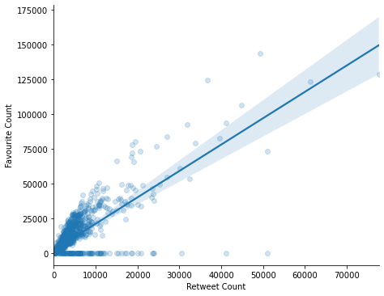

```python
sns.lmplot(x="retweet_count",
           y="favorite_count",
           data=df,
           size = 5,
           aspect=1.3,
           scatter_kws={'alpha':1/5})

plt.xlabel('Retweet Count')
plt.ylabel('Favourite Count');
```

- `Favourite` and `retweet` counts are positively correlated.
- The majority of the data falls below 40000 favorites and 10000 retweets.

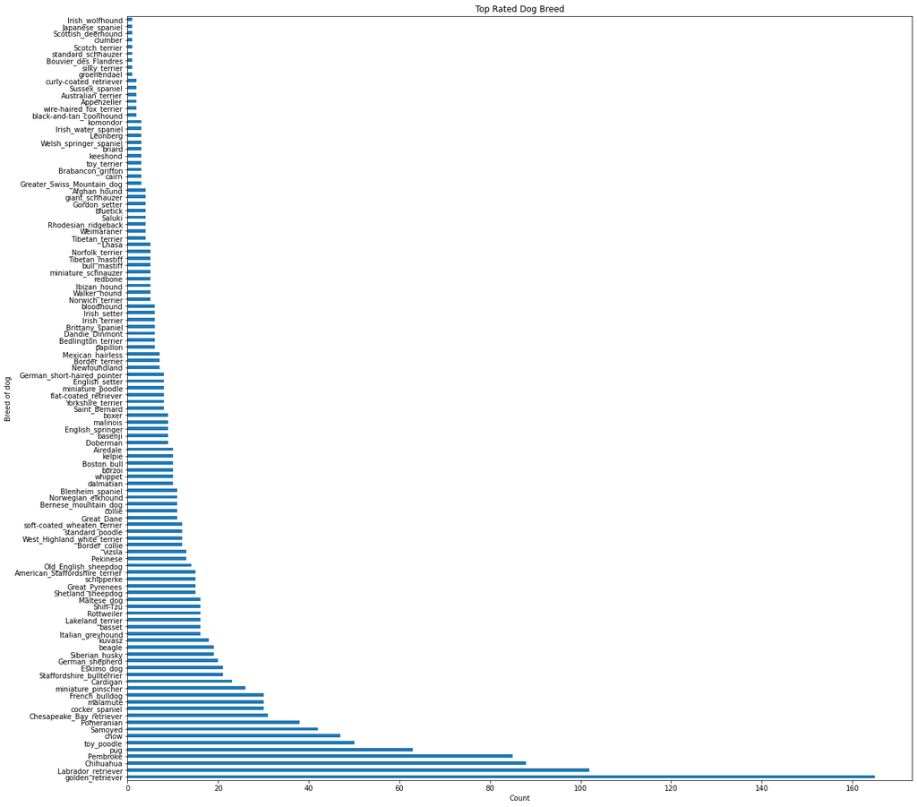

```python
df['breed_pred'].value_counts().plot(kind = 'barh')
plt.title('Top Rated Dog Breed')
plt.xlabel('Count')
plt.ylabel('Breed of dog');
```